# Same Smoother vs Pooled Smoother

Alan Cobo-Lewis

2025-02-11

## R Markdown

```r
library(tidyverse)
```

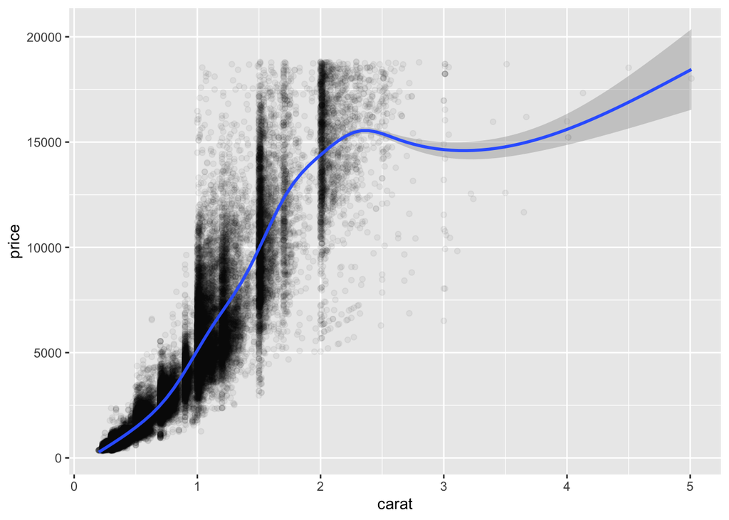

```r
ggplot(diamonds, aes(x=carat, y=price)) +
  geom_point(alpha=.05) +
  geom_smooth()
```

## Adding `aes(color=clarity)` overlays scatterplots and fits a different smoother to each clarity, 1 panel

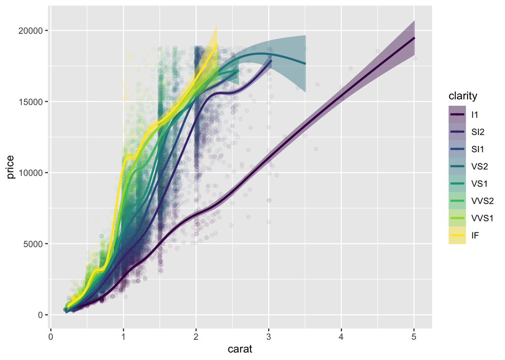

```r
ggplot(diamonds, aes(x=carat, y=price, color=clarity, fill=clarity)) +
  geom_point(alpha=.05) +
  geom_smooth()
```

## Moving `aes(color=clarity)` from `ggplot()` to `geom_point()` lets a single smoother fit the entire dataset, 1 panel

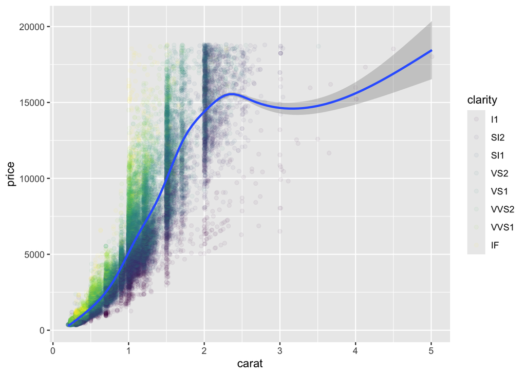

```r
ggplot(diamonds, aes(x=carat, y=price)) +
  geom_point(aes(color=clarity), alpha=.05) +
  geom_smooth()
```

## Using `facet_wrap(~clarity)` instead of `aes(color=clarity)` causes each panel to have its own smooth

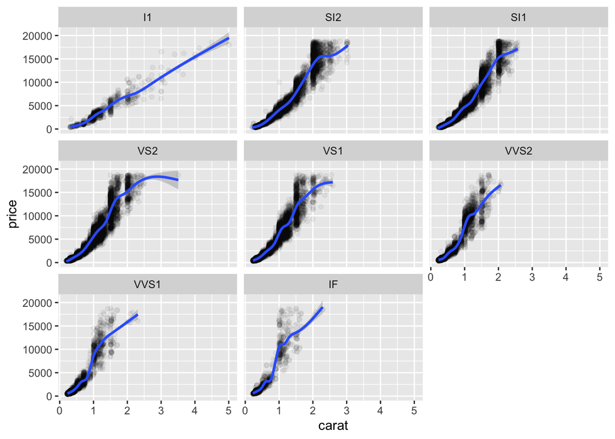

```r
ggplot(diamonds, aes(x=carat, y=price)) +
  geom_point(alpha=.05) +
  geom_smooth() +
  facet_wrap(~clarity)
```

## If you want the same smooth in each panel then you have to transform the data in `geom_smooth()` to ‘NULL out’ the facetting variable

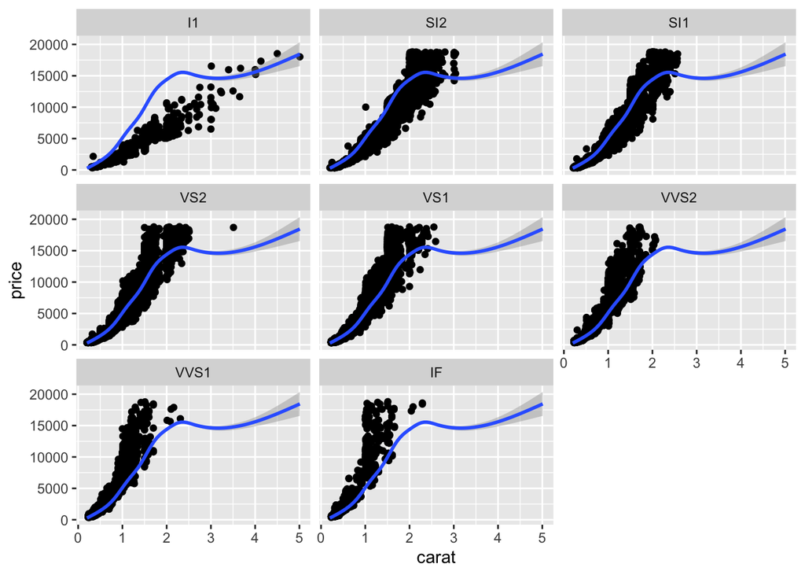

```r
ggplot(diamonds, aes(x=carat, y=price)) +
  geom_point() +
  geom_smooth(data=~transform(., clarity=NULL)) +
  facet_wrap(~clarity)
```

## With two calls to `geom_smooth()`, you can include both the individual *and* the pooled smooth line in each panel! (setting the pooled curve to `linetype='dashed'` and `color='black'` to make it easier to distinguish from panel-specific smooths)

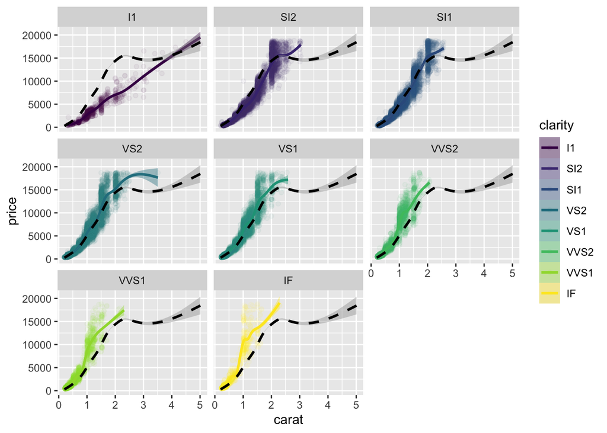

```r
ggplot(diamonds, aes(x=carat, y=price)) +
  geom_point(aes(color=clarity), alpha=.05) +
  geom_smooth(aes(color=clarity, fill=clarity)) +
  geom_smooth(data=~transform(., clarity=NULL), linetype='dashed', color='black') +
  facet_wrap(~clarity)
```

## Alternatively, `facet_grid()` (but not `facet_wrap()`) has a `margins=TRUE` option to get the pooled model…but it gets plotted in an extra panel instead of replicated in each of the individual panels (also you can’t wrap your panels)

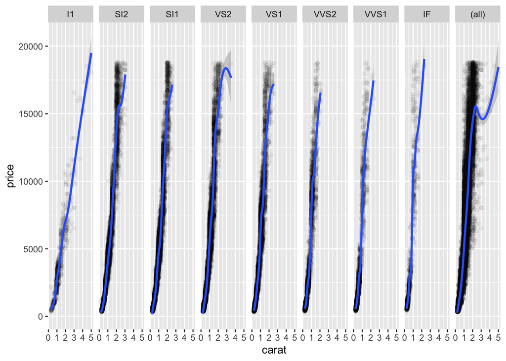

```r
ggplot(diamonds, aes(x=carat, y=price)) +
  geom_point(alpha=.05) +
  geom_smooth() +
  facet_grid(~clarity, margins=TRUE)
```